# clustering homework

kzaitsev

March 29, 2017

# Кластеризация

Тема этой домашней работы – кластеризация и разные её виды. В первой части домашней работы я хочу, чтобы вы на примере данных экспрессии из прошлой домашней работы разобрались, что с данными экспрессии обычно делают. В это домашней работе нам понадобятся следующие библиотеки:

```r
library(DESeq2)
library(ggplot2)
library(pheatmap)
library(amap)
library(dbscan)
options(width=120)
```

## Иерархическая кластеризация и K-means

Чаще всего при работе с данными экспрессии используется две кластеризации: иерархическая кластеризация в пространстве образцов и K-means в пространстве генов.

Первая нужна для того, чтобы понимать как ваши образцы соотносятся с дизайном эксперимента, который у вас есть, а также для поиска аутлаеров в вашем эксперименте (ведь если есть образцы, которые совсем не похожи на другие, должно быть это аутлаеры? Или нет? ).

Вторая нужна для описания паттернов экспрессии в ваших образцах + приятнее рисовать хитмапы, когда гены идут не как попало, а упорядочены в кластеры.

В обоих случаях, мы будем использовать корреляцию (между образцами и между генами) как меру похожести для нашей кластеризации. И соотвественно 1 - cor(x, y) – как меру “непохожести”.

Также в обоих случаях, мы сначала оставим только 8000 самых сильно эспрессированных генов. Это делается за тем, что мало экспрессированные гены привносят шум в “паттерны” экспрессии, а так же невольно завышают корреляцию между образцами: ведь они слабо экспрессированы во всех образцах.

### Задание 1: иерархическая кластеризация

Используем иерархическую клатеризацию для обнаружения аутлаера

- Возьмем весь датасет **с аутлаером**
- Создадим DeseqDataSet объект (дизайн не важен)
- Оставим только 8000 экспрессированых генов
- Используем rlog(dds) для получения логарифмированных значений экспрессии
- Посчитаем корреляции между образцами используя cor (результатом будет матрица размера $m \times m$, где m – количество образцов)
- Посчитаем матрицу “непохожести” 1 - cor, и dist объект для этой матрицы
- Сделаем кластеризацию с помощью функции hclust, используя три разных метода “связывания” объектов в группы: average, complete and single
- Построим для каждой график с помощью plot

В результате должно получиться что-то около такого, только три:

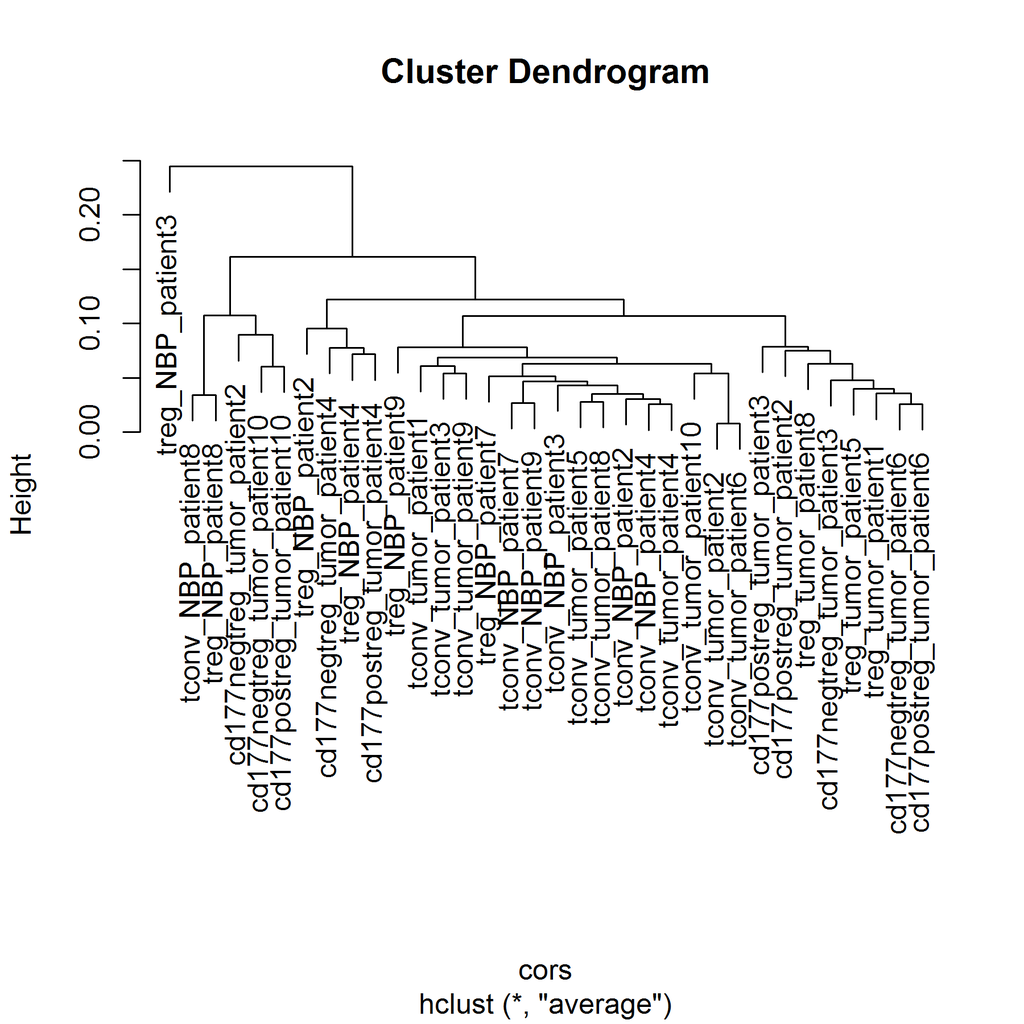

### Задание 2: K-means

Используем K-means для описания паттернов экспрессии

- Возьмем весь датасет **без аутлаера**
- Создадим DeseqDataSet объект (дизайн не важен)
- Оставим только 8000 экспрессированных генов
- Используем rlog(dds) для получения логарифмированных значений экспрессии
- Используем функцию Kmeans из пакета amap с методом “correlation”, c количеством кластеров равным 6. (Вы можете выбрать своё количество кластеров), и максимальным количеством итераций равным 20000
- После этого вы можете достать соотвествие каждого гена кластеру с помощью элемента листа с названием “cluster”
- После этого от вас потребуется эту кластеризацию изобразить на хитмапе: гены должны быть отсортированы по кластерам, а столбцы сначала по клеткам, а затем по тканям.

Пример использования функции Kmeans:

```r
clustering <- Kmeans(rld, 6, method="correlation", iter.max=20000)
head(clustering$cluster)
```

```
## ENSG00000166710 ENSG00000210082 ENSG00000251562 ENSG00000075624 ENSG00000198804 ENSG00000198938
##               6               4               5               6               1               1
```

Должно получиться что-то в духе:

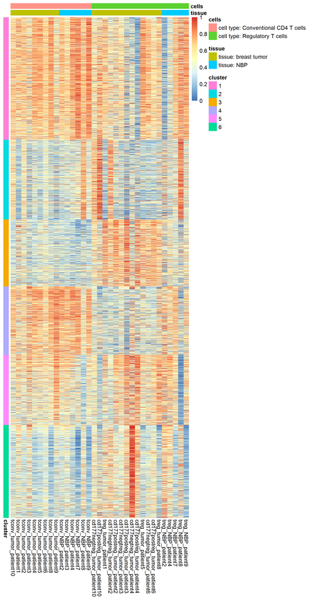

## Density based algortihms

Как вы наверное помните, у нас есть алгоритмы, которые позволяют находить “плотные” кластеры, и при этом им не нужно указывать число кластеров. Пример такого алгоритма (DBSCAN) был на журнальном клубе посвящённому single-cell RNA-seq. В этом задании от вас потребуется запустить DBSCAN и подобрать к нему аргументы так, чтобы картинка была похожа на что-нибудь разумное.

В архиве находится файлик **projection.csv**, который содержит в себе результаты анализа данных single-cell RNA-seq, а именно tSNE-проекции всех клеток. По сути каждая клетка здесь определена в двух-мерном пространстве, и клетки транскрипционные профили которых бризки друг к другу находятся на этой проекции близко, а те, что транскрипционно различаются – находятся дальше.

Базовая концепция алгоритма DBSCAN очень простая – для каждой точки, мы можем посмотреть количество точек-соседей, которые находятся к ней ближе чем на какое-то расстояние $\epsilon$. Если количество точек, в этой $\epsilon$-окрестности больше или равно заранее определенного числа $k$, и какие-то из этих точек-соседей уже лежат в кластере – то нашу точку можно в этот кластер добавить.

Пакет **dbscan** доступен из CRAN, функция **dbscan** принимает, кроме объекта с точками в пространстве, два аргумента: радиус окружности вокруг точки $\epsilon$, в которой мы пытаемся найти достаточноe число соседей, и достаточно число соседей $k$ в этой окружности.

Ознакомиться с пакетом можно тут: https://cran.r-project.org/web/packages/dbscan/vignettes/dbscan.pdf , там же можно ознакомиться и с работой алгоритма и базовой простой концепцией.

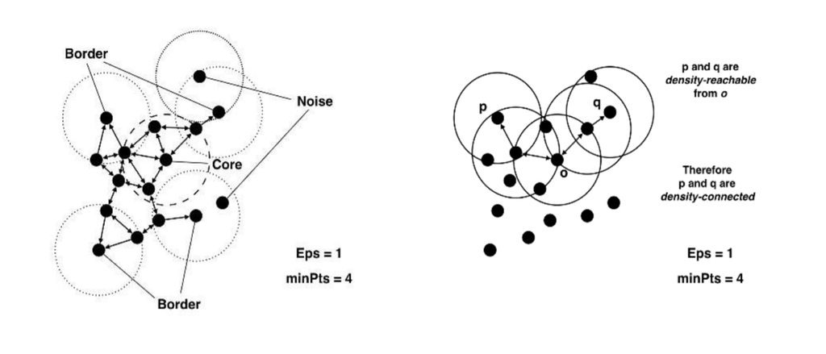

Из оригинальной статьи пакета dbscan

От вас же хочется увидеть подобранные значения количества соседей и радиуса окружности, данные до кластеризации и после кластеризации, что-то в духе:

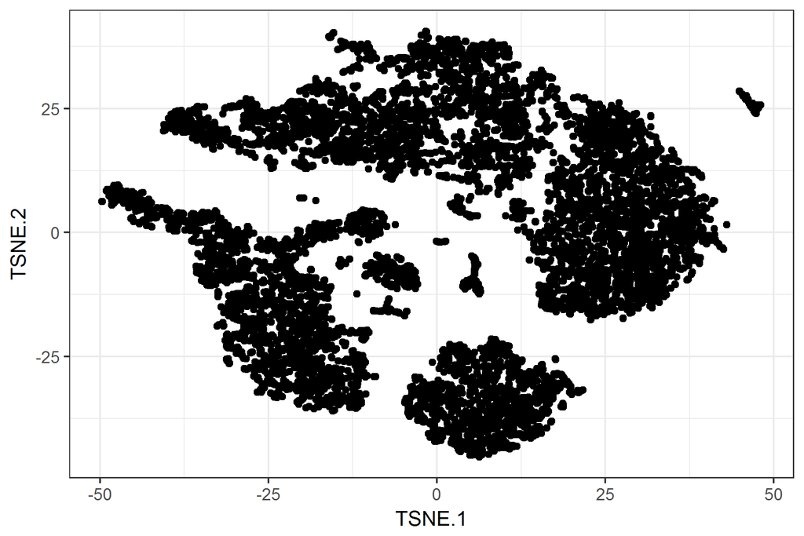

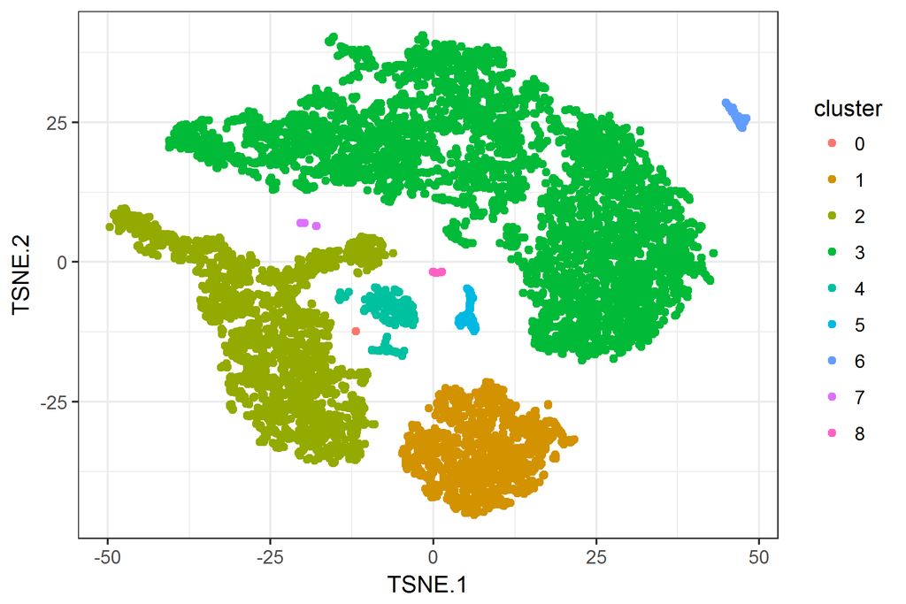